# HW - Cluster Analysis

2024-03-08

```r
library(cluster)
library(readr)
library(factoextra)
library(magrittr)
library(NbClust)

data <- read.csv("C:/Users/rusha/Downloads/Multivariate/credit_risk_dataset.csv/credit data .csv", header=TRUE, fill = TRUE)
data <- na.omit(data[,2:6])
```

```r
str(data)
```

```
## 'data.frame':    446 obs. of  5 variables:
##  $ person_home_ownership     : chr  "RENT" "OWN" "MORTGAGE" "RENT" ...
##  $ person_income             : int  59000 9600 9600 65500 54400 9900 77100 78956 83000 10000 ...
##  $ loan_amnt                 : int  35000 1000 5500 35000 35000 2500 35000 35000 35000 1600 ...
##  $ loan_int_rate             : num  16 11.1 12.9 15.2 14.3 ...
##  $ cb_person_cred_hist_length: int  3 2 3 2 4 2 3 4 2 3 ...
##  - attr(*, "na.action")= 'omit' Named int [1:52] 40 51 58 60 63 71 72 85 86 88 ...
##   ..- attr(*, "names")= chr [1:52] "40" "51" "58" "60" ...
```

```r
data$person_home_ownership <- as.factor(data$person_home_ownership)
data$person_income <- as.numeric(data$person_income)
data$loan_amnt <- as.numeric(data$loan_amnt)
data$cb_person_cred_hist_length <- as.numeric(data$cb_person_cred_hist_length)
str(data)
```

```
## 'data.frame':    446 obs. of  5 variables:
##  $ person_home_ownership     : Factor w/ 4 levels "MORTGAGE","OTHER",..: 4 3 1 4 4 3 4 4 4 3 ...
##  $ person_income             : num  59000 9600 9600 65500 54400 ...
##  $ loan_amnt                 : num  35000 1000 5500 35000 35000 2500 35000 35000 35000 1600 ...
##  $ loan_int_rate             : num  16 11.1 12.9 15.2 14.3 ...
##  $ cb_person_cred_hist_length: num  3 2 3 2 4 2 3 4 2 3 ...
##  - attr(*, "na.action")= 'omit' Named int [1:52] 40 51 58 60 63 71 72 85 86 88 ...
##   ..- attr(*, "names")= chr [1:52] "40" "51" "58" "60" ...
```

# Hierarchical Clustering

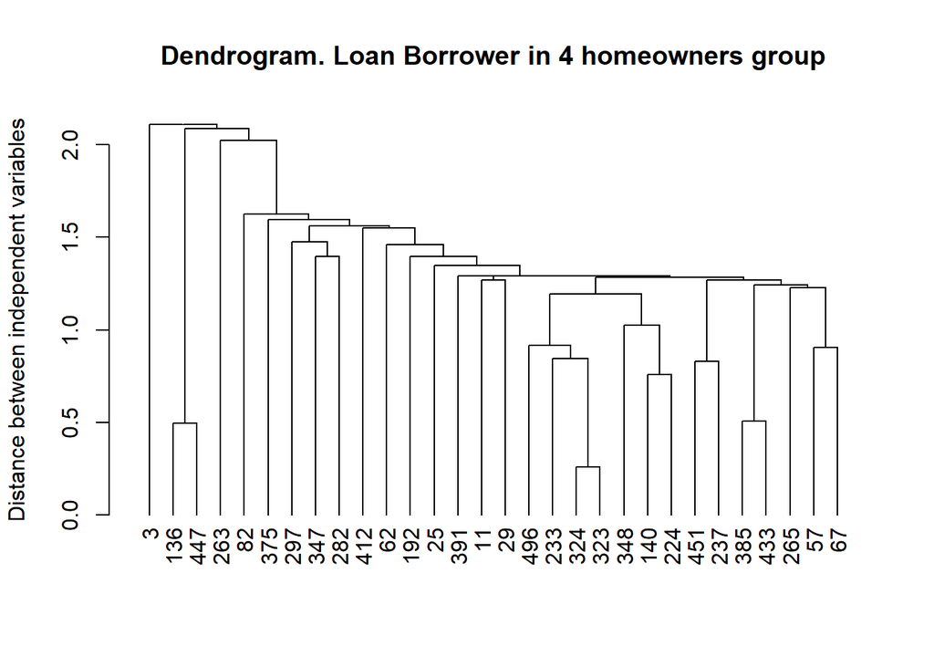

```r
#Since the dataset is of 446 observations, I am creating a sample data of only first 30 rows of the entire data.
sampled_data <- data[sample(nrow(data), 30), ]
matstd.data <- scale(sampled_data[,-1])

# Creating a (Euclidean) distance matrix of the standardized data
dist.data <- dist(matstd.data, method="euclidean")
colnames(dist.data) <- rownames(dist.data)

# Invoking hclust command (cluster analysis by single linkage method)
clusdata.nn <- hclust(dist.data, method = "single")

#dendogram
#plot(as.dendrogram(clusdata.nn),ylab="Distance between independent variables",
#     main="Dendrogram. People employed in nine industry groups \n  from European countries")

options(repr.plot.width=10, repr.plot.height=6)  # Adjust the plot size as needed
plot(as.dendrogram(clusdata.nn), ylab="Distance between independent variables",
     main="Dendrogram. Loan Borrower in 4 homeowners group")
```

```r
(agn.data <- agnes(sampled_data, metric="euclidean", stand=TRUE, method = "single"))
```

```
## Call:     agnes(x = sampled_data, metric = "euclidean", stand = TRUE, method = "single")
## Agglomerative coefficient:  0.5282052
## Order of objects:
##  [1] 347 282 237 140 348 391 375 451 385 433 11  29  25  192 324 323 233 496 265
## [20] 57  67  412 62  82  297 224 263 136 447 3
## Height (summary):
##    Min. 1st Qu.  Median    Mean 3rd Qu.    Max.
##  0.3311  1.5077  1.7057  1.7140  2.0139  3.1501
##
## Available components:
## [1] "order"     "height"    "ac"        "merge"     "diss"      "call"
## [7] "method"    "order.lab" "data"
```

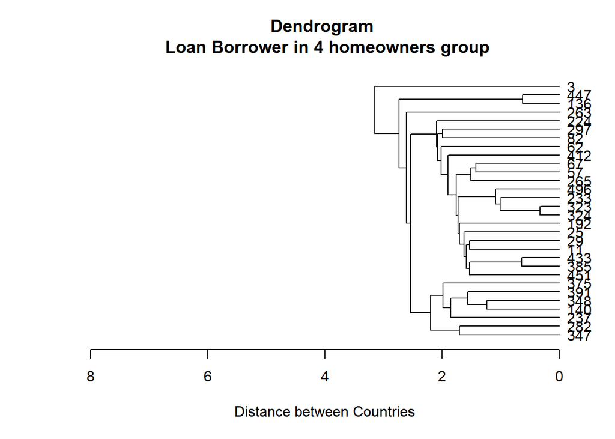

```r
plot(as.dendrogram(agn.data), xlab= "Distance between Countries",xlim=c(8,0),
     horiz = TRUE,main="Dendrogram \n Loan Borrower in 4 homeowners group")
```

For the hierarchical clustering method Reading from top to bottom, I think the optimal number of clusters are 4. Reason- From the dendrogram we can see that the clusters are divided into 2 groups in first break. Then the second break is divided into 2 more breaks. That is 3 clusters. But the optimal would be 4 clusters. First cluster + 2nd cluster i.e many cluster in one + 3rd cluster + 4th cluster

# Non-hierarchical clustering/ K-means clustering

```r
# K-means, k=2, 3, 4, 5, 6
# Centers (k's) are numbers thus, 10 random sets are chosen

(kmeans2.data <- kmeans(matstd.data,2,nstart = 10))
```

```
## K-means clustering with 2 clusters of sizes 17, 13
##
## Cluster means:
##   person_income  loan_amnt loan_int_rate cb_person_cred_hist_length
## 1     0.5283802 -0.1806810   0.006225764                 -0.7012260
## 2    -0.6909587  0.2362752  -0.008141384                  0.9169879
##
## Clustering vector:
## 347 451  11 237 385 324   3 412 140 265 391 496 348 233  29 282 375  82  57 297
##   1   2   2   2   2   1   2   2   1   1   1   1   1   1   2   1   2   1   1   1
## 224  67 433 192 263 136 447 323  25  62
##   1   1   2   2   1   2   2   1   2   1
##
## Within cluster sum of squares by cluster:
## [1] 45.71244 38.76219
##  (between_SS / total_SS =  27.2 %)
##
## Available components:
##
## [1] "cluster"      "centers"      "totss"        "withinss"     "tot.withinss"
## [6] "betweenss"    "size"         "iter"         "ifault"
```

```r
# Computing the percentage of variation accounted for. Two clusters
perc.var.2 <- round(100*(1 - kmeans2.data$betweenss/kmeans2.data$totss),1)
names(perc.var.2) <- "Perc. 2 clus"
perc.var.2
```

```
## Perc. 2 clus
##         72.8
```

```r
# Computing the percentage of variation accounted for. Three clusters
(kmeans3.data <- kmeans(matstd.data,3,nstart = 10))
```

```
## K-means clustering with 3 clusters of sizes 15, 9, 6
##
## Cluster means:
##   person_income  loan_amnt loan_int_rate cb_person_cred_hist_length
## 1     0.6698756 -0.0499064     0.2203512                 -0.7249161
## 2    -0.5385588  0.8922116     0.3460459                  0.8860086
## 3    -0.8668507 -1.2135514    -1.0699470                  0.4832774
##
## Clustering vector:
## 347 451  11 237 385 324   3 412 140 265 391 496 348 233  29 282 375  82  57 297
##   3   2   2   2   2   1   3   2   1   1   1   1   1   1   2   1   3   1   1   1
## 224  67 433 192 263 136 447 323  25  62
##   1   1   2   2   3   3   3   1   2   1
##
## Within cluster sum of squares by cluster:
## [1] 32.26250 15.08363 13.74214
##  (between_SS / total_SS =  47.3 %)
##
## Available components:
##
## [1] "cluster"      "centers"      "totss"        "withinss"     "tot.withinss"
## [6] "betweenss"    "size"         "iter"         "ifault"
```

```r
perc.var.3 <- round(100*(1 - kmeans3.data$betweenss/kmeans3.data$totss),1)
names(perc.var.3) <- "Perc. 3 clus"
perc.var.3
```

```
## Perc. 3 clus
##         52.7
```

```r
# Computing the percentage of variation accounted for. Four clusters
(kmeans4.data <- kmeans(matstd.data,4,nstart = 10))
```

```
## K-means clustering with 4 clusters of sizes 5, 9, 10, 6
##
## Cluster means:
##   person_income  loan_amnt loan_int_rate cb_person_cred_hist_length
## 1     1.2348552 -0.9719182   -0.09265162                 -0.6443699
## 2    -0.5385588  0.8922116    0.34604591                  0.8860086
## 3     0.3873858  0.4110995    0.37685267                 -0.7651892
## 4    -0.8668507 -1.2135514   -1.06994695                  0.4832774
##
## Clustering vector:
## 347 451  11 237 385 324   3 412 140 265 391 496 348 233  29 282 375  82  57 297
##   4   2   2   2   2   3   4   2   3   3   3   3   3   3   2   1   4   1   1   1
## 224  67 433 192 263 136 447 323  25  62
##   3   3   2   2   4   4   4   3   2   1
##
## Within cluster sum of squares by cluster:
## [1]  7.566929 15.083629 15.142326 13.742141
##  (between_SS / total_SS =  55.6 %)
##
## Available components:
##
## [1] "cluster"      "centers"      "totss"        "withinss"     "tot.withinss"
## [6] "betweenss"    "size"         "iter"         "ifault"
```

```r
perc.var.4 <- round(100*(1 - kmeans4.data$betweenss/kmeans4.data$totss),1)
names(perc.var.4) <- "Perc. 4 clus"
perc.var.4
```

```
## Perc. 4 clus
##         44.4
```

```r
# Computing the percentage of variation accounted for. Five clusters
(kmeans5.data <- kmeans(matstd.data,5,nstart = 10))
```

```
## K-means clustering with 5 clusters of sizes 9, 7, 5, 4, 5
##
## Cluster means:
##   person_income   loan_amnt loan_int_rate cb_person_cred_hist_length
## 1     1.0702488 -0.04009267     0.6251960                 -0.4564287
## 2    -0.4538728  0.83732994     0.7036863                  0.9435416
## 3    -0.3012064  0.77731916    -0.3438867                 -0.8860086
## 4    -0.4868871 -1.38768525    -0.4892838                 -0.8255989
## 5    -0.6003097 -0.76726607    -1.3751999                  1.0471010
##
## Clustering vector:
## 347 451  11 237 385 324   3 412 140 265 391 496 348 233  29 282 375  82  57 297
##   5   2   2   2   2   3   4   2   1   1   1   3   1   3   3   4   5   1   1   4
## 224  67 433 192 263 136 447 323  25  62
##   1   1   2   5   4   5   5   3   2   1
##
## Within cluster sum of squares by cluster:
## [1] 14.610157  9.310038  3.815985  7.895548  8.594782
##  (between_SS / total_SS =  61.9 %)
##
## Available components:
##
## [1] "cluster"      "centers"      "totss"        "withinss"     "tot.withinss"
## [6] "betweenss"    "size"         "iter"         "ifault"
```

```r
perc.var.5 <- round(100*(1 - kmeans5.data$betweenss/kmeans5.data$totss),1)
names(perc.var.5) <- "Perc. 5 clus"
perc.var.5
```

```
## Perc. 5 clus
##         38.1
```

```r
# Computing the percentage of variation accounted for. Six clusters
(kmeans6.data <- kmeans(matstd.data,6,nstart = 10))
```

```
## K-means clustering with 6 clusters of sizes 4, 5, 7, 5, 4, 5
##
## Cluster means:
##   person_income  loan_amnt loan_int_rate cb_person_cred_hist_length
## 1   0.581249012  0.1148924     1.2917441                 -0.8255989
## 2  -0.301206418  0.7773192    -0.3438867                 -0.8860086
## 3  -0.453872826  0.8373299     0.7036863                  0.9435416
## 4   1.461448578 -0.1640808     0.0919576                 -0.1610925
## 5   0.002176975 -1.2772808    -1.0861407                 -0.8255989
## 6  -0.991560994 -0.8555896    -0.8977144                  1.0471010
##
## Clustering vector:
## 347 451  11 237 385 324   3 412 140 265 391 496 348 233  29 282 375  82  57 297
##   5   3   3   3   3   2   6   3   1   4   1   2   1   2   2   5   6   4   4   5
## 224  67 433 192 263 136 447 323  25  62
##   1   4   3   6   5   6   6   2   3   4
##
## Within cluster sum of squares by cluster:
## [1] 2.166051 3.815985 9.310038 6.369364 6.503533 9.946326
##  (between_SS / total_SS =  67.1 %)
##
## Available components:
##
## [1] "cluster"      "centers"      "totss"        "withinss"     "tot.withinss"
## [6] "betweenss"    "size"         "iter"         "ifault"
```

```r
perc.var.6 <- round(100*(1 - kmeans6.data$betweenss/kmeans6.data$totss),1)
names(perc.var.6) <- "Perc. 6 clus"
perc.var.6
```

```
## Perc. 6 clus
##         32.9
```

```r
attributes(perc.var.6)
```

```
## $names
## [1] "Perc. 6 clus"
```

```r
# Computing the percentage of variation accounted for. Seven clusters
(kmeans7.data <- kmeans(matstd.data,7,nstart = 10))
```

```
## K-means clustering with 7 clusters of sizes 7, 5, 3, 4, 5, 3, 3
##
## Cluster means:
##   person_income  loan_amnt loan_int_rate cb_person_cred_hist_length
## 1   -0.31899580  0.6065192    0.98278139                 0.77094252
## 2   -0.07964842  0.5942093    0.04684633                -1.12764727
## 3   -0.75523246  1.3086967   -0.74086597                 0.88600857
## 4   -1.03385843 -1.2395817   -0.80506279                 0.98669136
## 5    1.10619040 -0.8211219    0.60900224                -0.88600857
## 6    1.34329103  0.4649553   -0.08270401                 0.08054623
## 7   -0.17616043 -1.1579004   -1.48925049                -0.72491610
##
## Clustering vector:
## 347 451  11 237 385 324   3 412 140 265 391 496 348 233  29 282 375  82  57 297
##   7   1   3   1   1   2   4   1   5   6   1   2   2   2   3   7   4   5   6   5
## 224  67 433 192 263 136 447 323  25  62
##   5   6   1   3   7   4   4   2   1   5
##
## Within cluster sum of squares by cluster:
## [1] 8.402612 4.063527 2.066048 6.716874 5.709514 1.311752 3.879249
##  (between_SS / total_SS =  72.3 %)
##
## Available components:
##
## [1] "cluster"      "centers"      "totss"        "withinss"     "tot.withinss"
## [6] "betweenss"    "size"         "iter"         "ifault"
```

```r
perc.var.7 <- round(100*(1 - kmeans7.data$betweenss/kmeans7.data$totss),1)
names(perc.var.7) <- "Perc. 7 clus"
perc.var.7
```

```
## Perc. 7 clus
##         27.7
```